# Las Wagones - 03/18/2021

## Customer Segmentation Overview

### What is at stake?

The Sales team of *Las Wagones* has identified 4 - rather balanced - customer segments based on a study of the historical buying behavior of the customers.

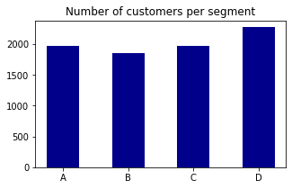

```python
plot_first_graph()
```

In order to better understand who are the customers behind these segments, we want to identify the key differentiation criteria that characterize these four groups. Indeed these criteria might not be obvious at first glance!

### Quantitative Differentiation Criteria

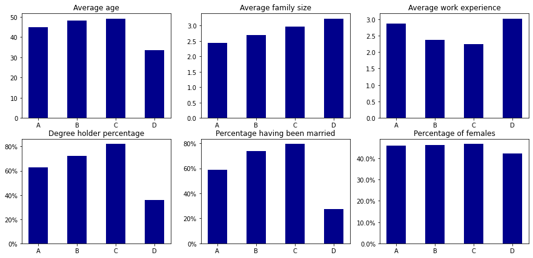

```python
plot_quanti_graphs()
```

**Key observation:** With younger individuals, larger families, more work experience, less degree holders and less married individuals, the D segment clearly stands out.

### Qualitative Differentiation Criteria

We retrieve this strong differentiation of segment D in the profession mix. Interestingly, this segment seems to display strong variations in the size of the first order with more "Low" and "High" ones.

```python
get_pivot_tables()[1]
```

| Segmentation | Top three professions | Spending score frequency order |
| --- | --- | --- |
| A | Artist - Entertainment - Engineer | Low - Average - High |
| B | Artist - Entertainment - Engineer | Low - Average - High |
| C | Artist - Executive - Entertainment | Average - Low - High |
| D | Healthcare - Entertainment - Doctor | Low - High - Average |

**Additional observation:** In previous graphs, C displayed a larger share of individuals holding a degree and it appears as the only segment in which "Executives" are among the most represented professions.

This constatation, associated with the higher number of married individuals and the relatively large size of families, differentiates segment C.

### Focus on A and B segments

The profession mix does not seem strongly distinctive for these two segments, except maybe the share of artists. The size of the first order is however more telling.

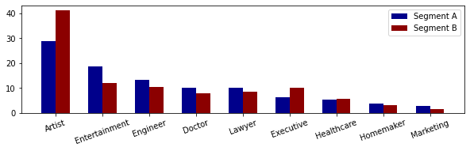

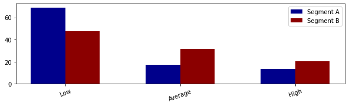

```python
plot_comparison('Profession'), plot_comparison('Spending_Score');
```